# Concussions from 2012-2014 NFL Seasons

Serena Amro Gazze, Arjun Vadlamudi, Anirudhh Venkat

2025-02-17

*Serena Amro Gazze: Analysis of NFL Concussions relative to Positions*

*Question 1a: Do offensive or defensive football positions result in more head injuries?*

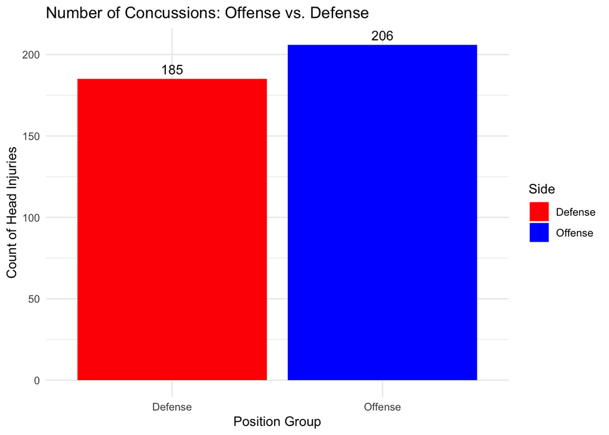

*Question 1b: Which positions have the most and least head injuries?*

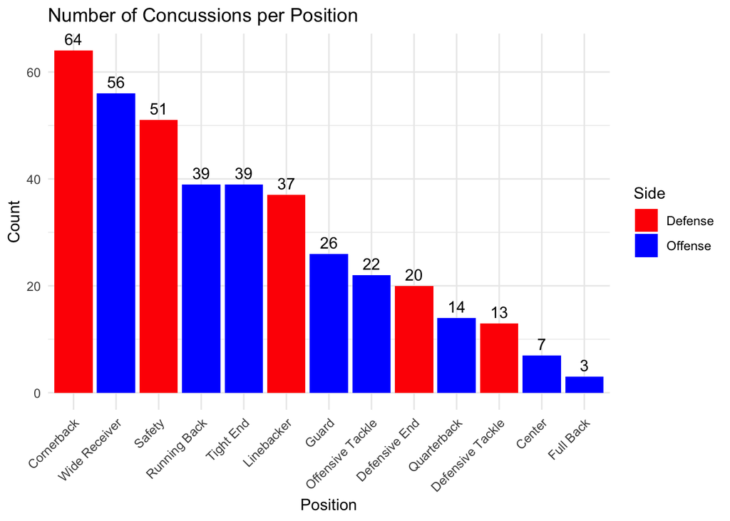

*Question 1c: Which positions result in the top 5 numbers of head injuries?*

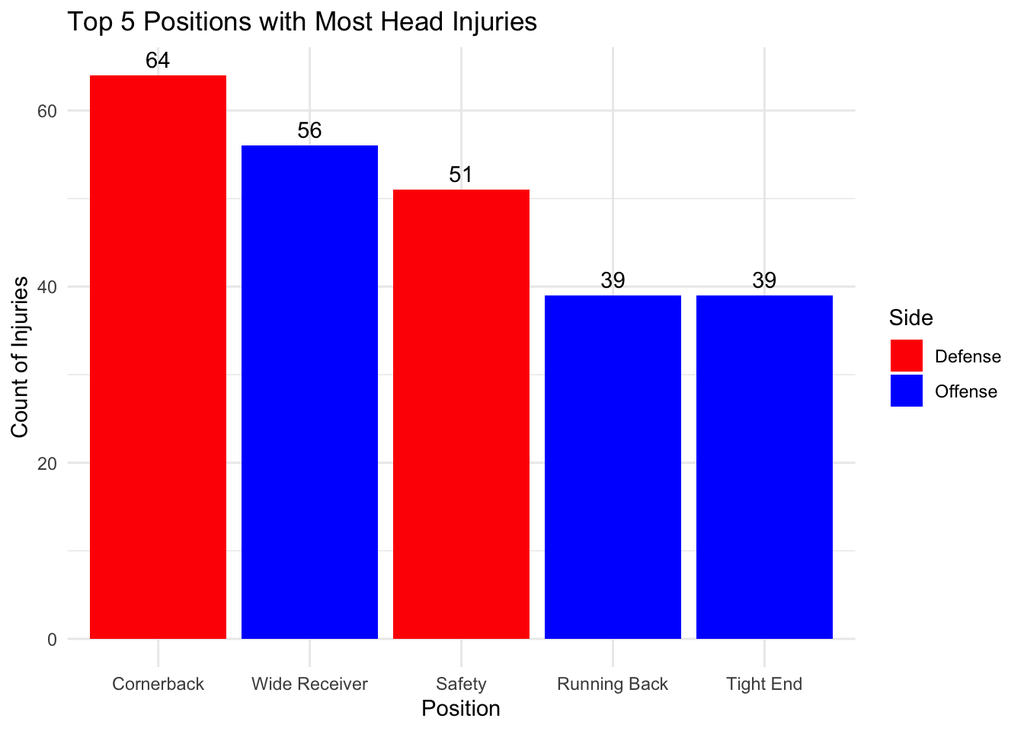

*Question 1d: Which positions result in the bottom 5 numbers of head injuries?*

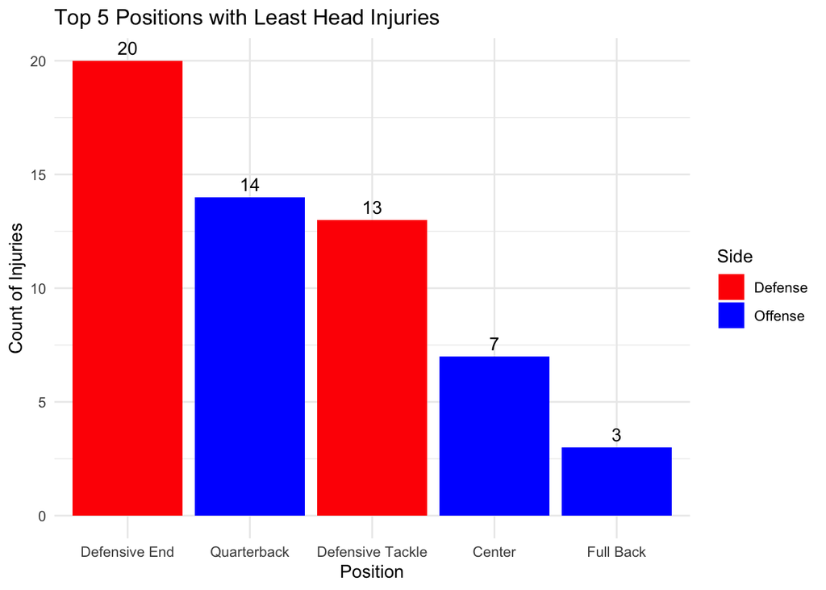

*Question 1e: Which offensive positions result in the most and least head injuries?*

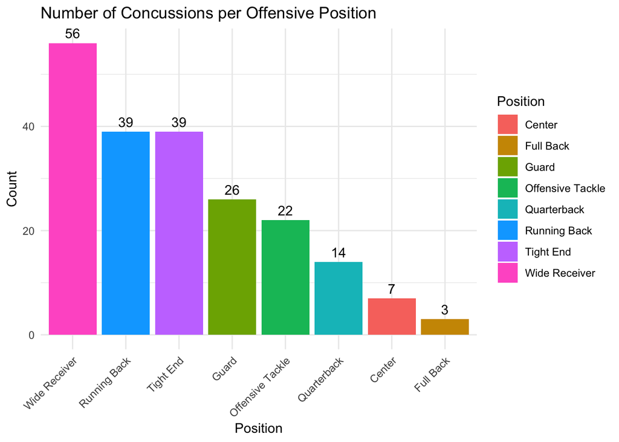

*Question 1f: Which defensive positions result in the most and least head injuries?*

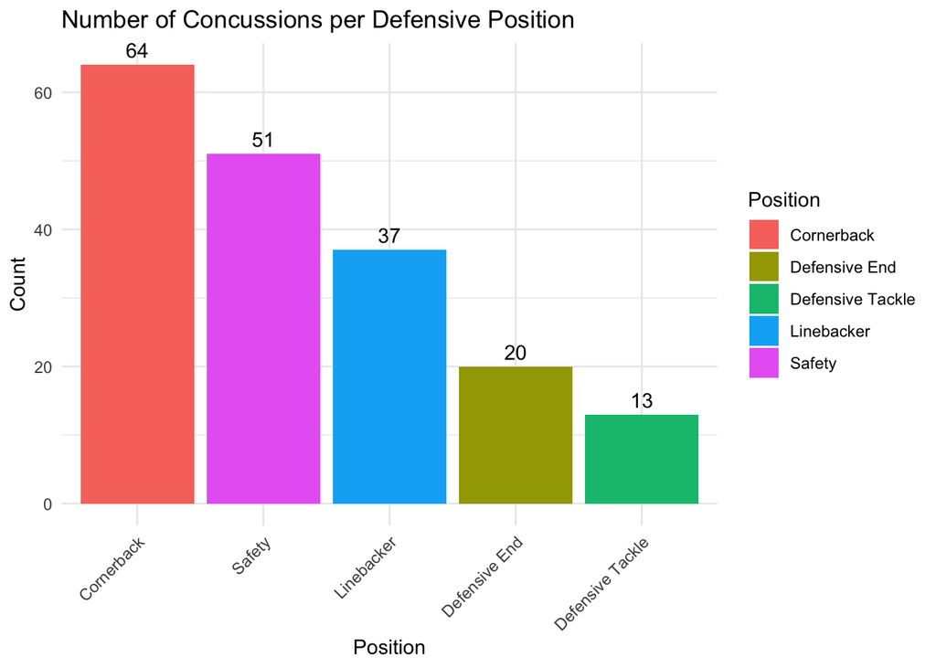

*Question 1g: Is there a trend in concussion frequency over different seasons (2012-2014 seasons)?*

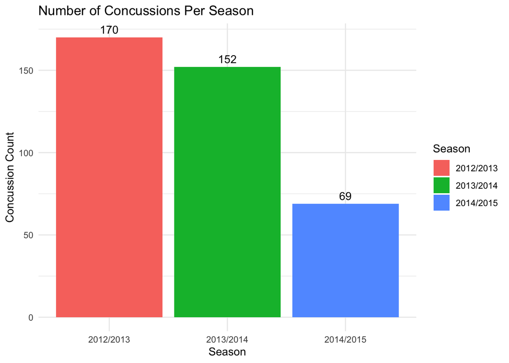

*Question 1h: Is there a trend in concussion frequency for offensive positions over different seasons (2012-2014)?*

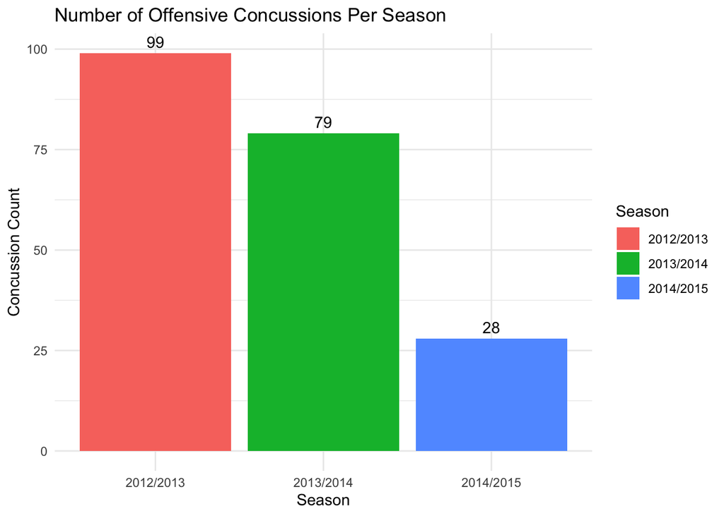

*Question 1i: Is there a trend in concussion frequency for defensive positions over different seasons (2012-2014)?*

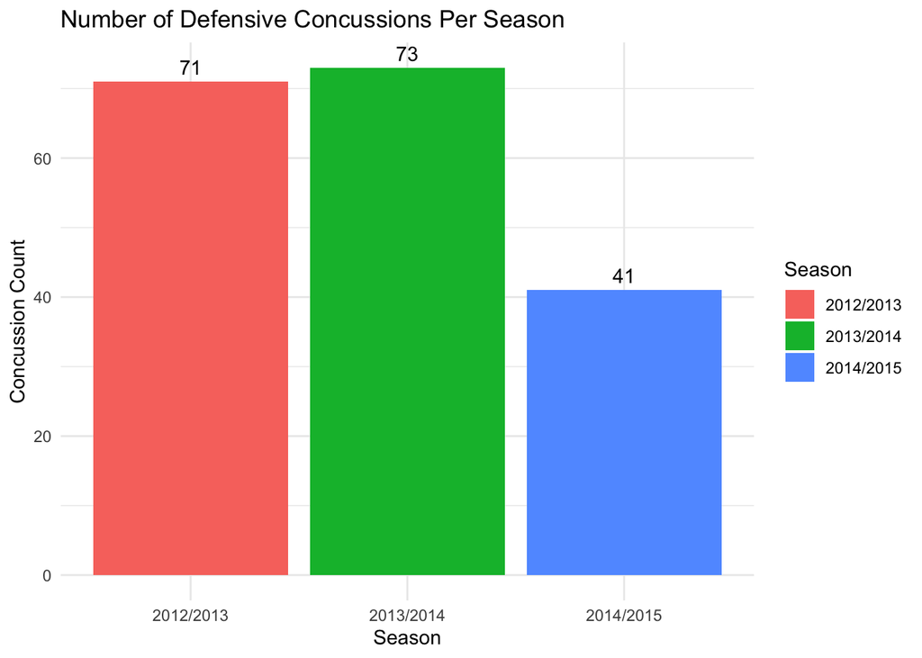

*Arjun Vadlamudi: Analysis of Injury Type relative to Seasons* *Question 2a: How does the season correlate with injury type?*

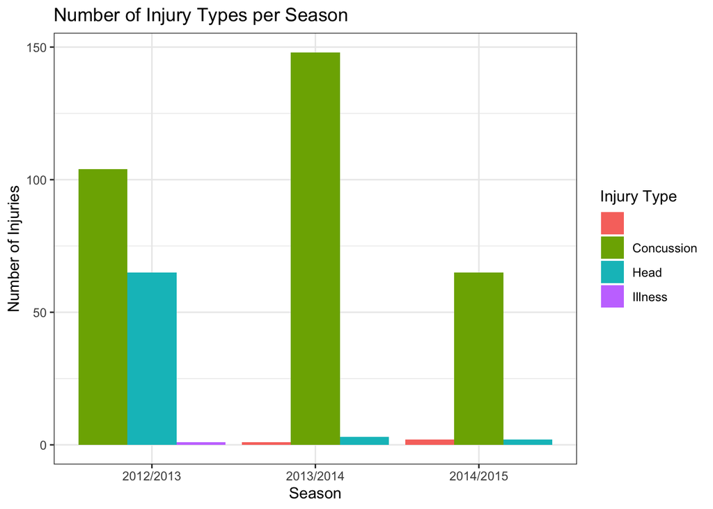

*Question 2b: How does injury type affect team’s performance?*

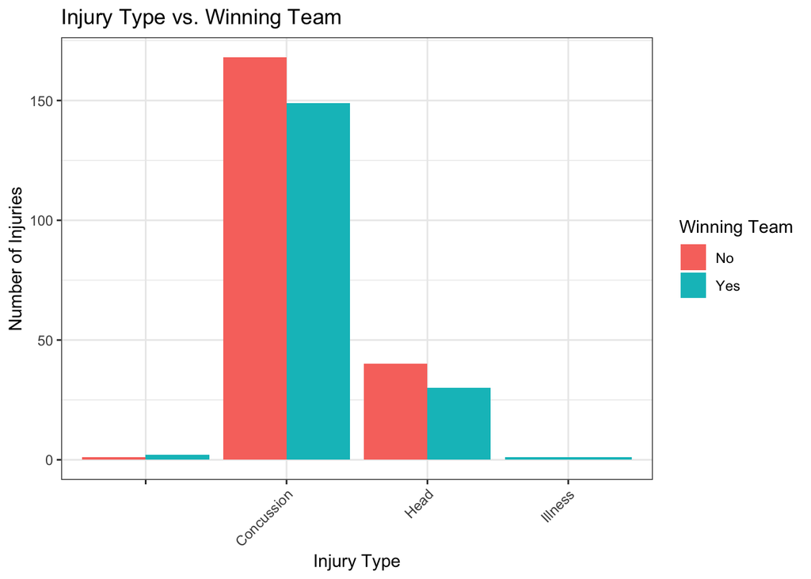

*Anirudhh Venkat: Analysis of Teams Causing the Most Head Injuries* *Question 3a: Which team has the most injuries?*

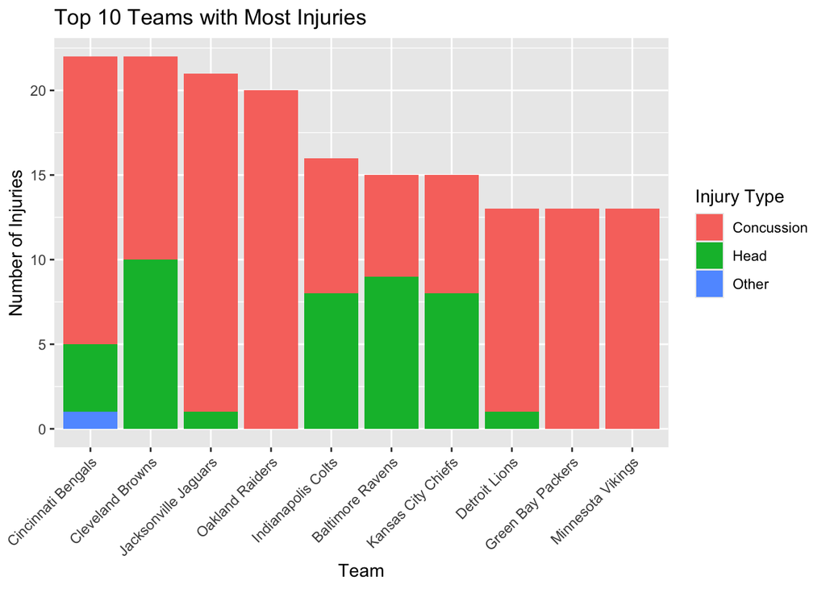

*Question 3b: Which team causes the most injuries?*

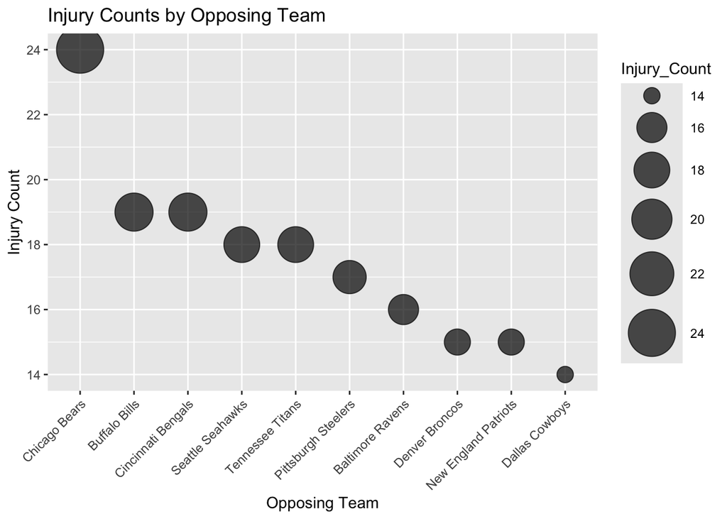